# To Be Immersed or Not to Be: AI Companions for Dementia Care

Pre-registered Analysis Report

Kineta H. Tober | Supervised by Stéphane Bouchard, Lisa Sheehy, & Andrew Frank

June 29, 2026

> **Pre-registration:** https://osf.io/65k7s  
> All analyses follow the pre-registered plan. Deviations are labelled **[Exploratory]** Reporting follows APA 7 and JARS-Quant (Appelbaum et al., 2018). The Appendix follows the References section and contains additional analyses that are tangentially related to the main research questions and are provided for completeness.

**Terminology and abbreviations.** The immersive virtual-reality condition is referred to as *IVR* in prose and labelled *VR* in the data, figures, and tables; the two labels denote the same condition. Abbreviations used throughout: CPS = Cognitive Performance Scale (dementia-staging eligibility measure); LTC = long-term care; UCLA-3 = three-item UCLA Loneliness Scale; SP = social presence; EN = engagement; AT = AI attitudes; US = usability; η²G = generalised eta-squared. All are defined again at first substantive use.

# 1 Packages and Setup

This section loads the R packages used throughout the analysis, defines a consistent colour palette for VR and Desktop conditions across all figures, and sets a shared plotting theme so every figure in this report follows the same visual style.

R packages loaded for this analysis.

| Package | Purpose | Version |
| --- | --- | --- |
| tidyverse | Data wrangling, reshaping, and all figures (ggplot2) | 2.0.0 |
| lubridate | Session date parsing for counterbalancing order derivation | 1.9.5 |
| ez | Mixed ANOVA with Type III sums of squares (ezANOVA) | 4.5.0 |
| lme4 | Loaded for the pre-registered loneliness mixed model, which was replaced by Spearman correlations once the baseline measure was confirmed time-invariant (see Exploratory Analyses) | 2.0.1 |
| lmerTest | Companion to lme4 (loaded with it; see note above) | 3.2.1 |
| effectsize | Cohen’s d, rank-biserial r, and generalised eta-squared confidence intervals | 1.0.2 |
| car | Levene’s test for homogeneity of variance | 3.1.5 |
| kableExtra | Formatted APA-style tables in HTML output | 1.4.0 |

Note. Type III sums of squares require sum-to-zero (effects) coding. options(contrasts = c(‘contr.sum’, ‘contr.poly’)) was set before any model was run.

# 2 Data Preparation

## 2.1 Load and Clean

In this stage, the raw experimental data was loaded, verified, and cleaned for analysis.

**Key transformations completed:**

**Data Verification:** Confirmed the dataset contains exactly 44 rows, representing 22 participants across 2 testing sessions.

**Data Formatting:** Standardized participant IDs, converted session dates into a proper date format, and established factor levels for modalities (`VR`, `Desktop`) and care types (`Transitional`, `LTC`, `Excluded`).

**Variable Renaming:** Simplified the long composite index strings into cleaner score variables (`score_sp`, `score_en`, `score_at`, `score_us`).

> **Psychometric note.** Social presence, engagement, AI attitudes, and usability are analysed as composite indices built from their constituent items (sp1–sp4, en1–en3, at1–at3, us1–us2). Internal consistency for each composite, computed on the analysed sample, is reported in Appendix E. Cronbach’s alpha is shown for the multi-item scales; for the two-item usability scale, alpha is reported with the caveat that the Spearman–Brown coefficient is the more appropriate index for two items.

**Algorithmic Counterbalancing:** Automatically derived the testing order (`VR-first` vs. `Desktop-first`) for each participant by evaluating their earliest chronological session date.

## 2.2 Pre-registered Exclusions

P03 and P04 scored CPS = 0, outside the preregistered eligibility window of CPS 1–2. `raw_full` retains all 22 participants for Sensitivity Check 3.

Table 1. Excluded participants (CPS outside 1–2).

| participant_id | cps |
| --- | --- |
| P03 | 0 |
| P04 | 0 |

# 3 Descriptive Statistics

Table 2. Participant characteristics (N = 20).

| Characteristic | Value |
| --- | --- |
| Age (years) |  |
| M (SD) | 78.5 (10.7) |
| Mdn [range] | 80 [46–93] |
| Gender, n (%) |  |
| Female | 14 (70%) |
| Male | 6 (30%) |
| UCLA Loneliness (3–9) |  |
| M (SD) | 5.3 (2.0) |
| Mdn [range] | 6 [3–9] |
| Session duration (min) |  |
| M (SD) | 17.4 (12.2) |
| Mdn [range] | 14 [3–62] |

Note. M = mean; SD = standard deviation; Mdn = median. Session duration pooled across both sessions per participant.

Outcome descriptives by modality and UCLA Loneliness band distributions are in Appendices A and B.

# 4 Assumption Checks

Before each hypothesis test: (1) Levene’s test checks homogeneity of variance in difference scores across counterbalancing order groups; (2) Shapiro-Wilk tests normality of those difference scores. With only two within-subjects levels, sphericity is mathematically guaranteed and Mauchly’s test is unnecessary (Field, 2024).

**Decision rule:** if Shapiro-Wilk *p* < .05, the Wilcoxon (Step 6) becomes the primary test and the ANOVA is reported for completeness.

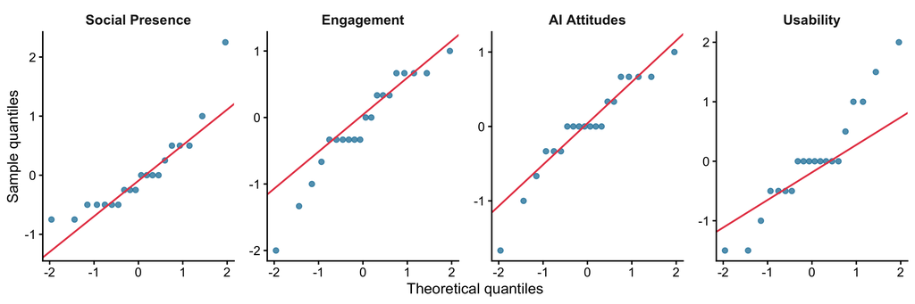

Figure 1. Q-Q plots of within-subject difference scores (VR − Desktop; Desktop − VR for H4). Points = observed; line = expected under normality.

# 5 Hypothesis Tests

Pre-registered analysis sequence per hypothesis:

| Step | Test | Purpose |
| --- | --- | --- |
| 1 | Levene’s test | Homogeneity of variance of difference scores across order groups |
| 2 | Shapiro-Wilk | Normality of within-person difference scores |
| 3 | Mixed ANOVA | Modality (within) × Order (between); Type III *SS*; η²G reported |
| 4 | One-tailed paired *t* | Directional follow-up; only run if ANOVA *p* < .05 |
| 5 | Cohen’s *d*, 95% CI | Effect size on raw scores |
| 6 | Wilcoxon signed-rank | Non-parametric check; primary if Step 2 violated |

H1 is tested at α = .05 (uncorrected primary outcome). H2–H4 are Holm–Bonferroni corrected across the three secondary Modality *p*-values.

## 5.1 H1: Social Presence — VR > Desktop

**Primary hypothesis; α = .05, uncorrected.**  
*Participants will report higher social presence in IVR than desktop.*

H1 Step 1: Levene’s test.

| F | df1 | df2 | p | Decision |
| --- | --- | --- | --- | --- |
| 1.424 | 1 | 18 | .248 | Met |

H1 Step 2: Shapiro-Wilk.

| W | p | Decision |
| --- | --- | --- |
| 0.83 | .003 | Violated — Wilcoxon primary |

H1 Step 3: Mixed ANOVA.

| Effect | F | dfn | dfd | p | η²G | 90% CI |
| --- | --- | --- | --- | --- | --- | --- |
| Modality (within) | 0.01 | 1 | 18 | .938 | 0.000 | [0, 1] |
| Order (between) | 6.71 | 1 | 18 | .018 | 0.227 | [0.07, 1] |
| Modality × Order | 0.75 | 1 | 18 | .397 | 0.009 | [0, 1] |

Note. F = F-statistic; df = degrees of freedom; p = p-value; η²G = generalised eta-squared with 90% CI (Olejnik & Algina, 2003; Steiger, 2004). Modality row bolded.

```
## Step 4 skipped — ANOVA modality p = .938
```

H1 Step 5: Cohen’s d.

| d | 95% CI | Note |
| --- | --- | --- |
| 0.018 | [-0.421, 0.456] | Positive = VR higher |

H1 Step 6: Wilcoxon signed-rank (supplementary).

| V | p | r_rb | 95% CI |
| --- | --- | --- | --- |
| 59 | .691 | -0.132 | [-0.560, 0.351] |

Normality violated; Wilcoxon (Step 6) is the primary test. Social Presence did not differ significantly between IVR and Desktop, *F*(1, 18) = 0.01, *p* = .938, η²G = 0, Cohen’s *d* = 0.02, 95% CI [-0.42, 0.46]. H1 was not supported.

## 5.2 H2: Engagement — VR > Desktop

**Secondary hypothesis; Holm–Bonferroni corrected.**  
*Participants will report higher engagement in IVR than desktop.*

H2 Step 1: Levene’s test.

| F | df1 | df2 | p | Decision |
| --- | --- | --- | --- | --- |
| 0.443 | 1 | 18 | .514 | Met |

H2 Step 2: Shapiro-Wilk.

| W | p | Decision |
| --- | --- | --- |
| 0.93 | .156 | Met — ANOVA primary |

H2 Step 3: Mixed ANOVA.

| Effect | F | dfn | dfd | p | η²G | 90% CI |
| --- | --- | --- | --- | --- | --- | --- |
| Modality (within) | 0.46 | 1 | 18 | .508 | 0.006 | [0, 1] |
| Order (between) | 6.16 | 1 | 18 | .023 | 0.209 | [0.06, 1] |
| Modality × Order | 0.01 | 1 | 18 | .924 | 0.000 | [0, 1] |

Note. F = F-statistic; df = degrees of freedom; p = p-value; η²G = generalised eta-squared with 90% CI (Olejnik & Algina, 2003; Steiger, 2004). Modality row bolded.

```
## Step 4 skipped — ANOVA modality p = .508
```

H2 Step 5: Cohen’s d.

| d | 95% CI | Note |
| --- | --- | --- |
| -0.155 | [-0.594, 0.288] | Positive = VR higher |

H2 Step 6: Wilcoxon (supplementary).

| V | p | r_rb | 95% CI |
| --- | --- | --- | --- |
| 73.5 | .708 | -0.14 | [-0.566, 0.344] |

## 5.3 H3: AI Attitudes — VR > Desktop

**Secondary hypothesis; Holm–Bonferroni corrected.**  
*Participants will report more positive AI attitudes after IVR than desktop.*

H3 Step 1: Levene’s test.

| F | df1 | df2 | p | Decision |
| --- | --- | --- | --- | --- |
| 0.106 | 1 | 18 | .749 | Met |

H3 Step 2: Shapiro-Wilk.

| W | p | Decision |
| --- | --- | --- |
| 0.922 | .108 | Met — ANOVA primary |

H3 Step 3: Mixed ANOVA.

| Effect | F | dfn | dfd | p | η²G | 90% CI |
| --- | --- | --- | --- | --- | --- | --- |
| Modality (within) | 0.00 | 1 | 18 | 1.000 | 0.000 | [0, 1] |
| Order (between) | 2.84 | 1 | 18 | .109 | 0.118 | [0, 1] |
| Modality × Order | 0.00 | 1 | 18 | 1.000 | 0.000 | [0, 1] |

Note. F = F-statistic; df = degrees of freedom; p = p-value; η²G = generalised eta-squared with 90% CI (Olejnik & Algina, 2003; Steiger, 2004). Modality row bolded.

```
## Step 4 skipped — ANOVA modality p = 1.000
```

H3 Step 5: Cohen’s d.

| d | 95% CI | Note |
| --- | --- | --- |
| 0 | [-0.438, 0.438] | Positive = VR higher |

H3 Step 6: Wilcoxon (supplementary).

| V | p | r_rb | 95% CI |
| --- | --- | --- | --- |
| 46.5 | .486 | 0.022 | [-0.445, 0.479] |

## 5.4 H4: Usability — Desktop > VR

**Secondary hypothesis; Holm–Bonferroni corrected.**  
*Participants will rate usability higher for desktop than IVR.*  
Difference scores are computed as Desktop − VR so that positive values support H4.

H4 Step 1: Levene’s test.

| F | df1 | df2 | p | Decision |
| --- | --- | --- | --- | --- |
| 2.057 | 1 | 18 | .169 | Met |

H4 Step 2: Shapiro-Wilk.

| W | p | Decision |
| --- | --- | --- |
| 0.929 | .144 | Met — ANOVA primary |

H4 Step 3: Mixed ANOVA (Desktop vs. VR).

| Effect | F | dfn | dfd | p | η²G | 90% CI |
| --- | --- | --- | --- | --- | --- | --- |
| Modality (within) | 0.00 | 1 | 18 | 1.000 | 0.000 | [0, 1] |
| Order (between) | 0.07 | 1 | 18 | .791 | 0.003 | [0, 1] |
| Modality × Order | 0.24 | 1 | 18 | .628 | 0.003 | [0, 1] |

Note. F = F-statistic; df = degrees of freedom; p = p-value; η²G = generalised eta-squared with 90% CI (Olejnik & Algina, 2003; Steiger, 2004). Modality row bolded.

```
## Step 4 skipped — ANOVA modality p = 1.000
```

H4 Step 5: Cohen’s d.

| d | 95% CI | Note |
| --- | --- | --- |
| 0 | [-0.438, 0.438] | Positive = Desktop higher |

H4 Step 6: Wilcoxon (supplementary).

| V | p | r_rb | 95% CI |
| --- | --- | --- | --- |
| 39 | .516 | 0 | [-0.462, 0.462] |

# 6 Summary Tables

Table 3. Mixed ANOVA: All Effects on Outcomes by Modality and Counterbalancing Order (N = 20).

| Outcome | Hypothesis | Expected Direction | Effect | F(1, 18) | p | p (Holm) | η²G | 90% CI | d | 95% CI (d) |
| --- | --- | --- | --- | --- | --- | --- | --- | --- | --- | --- |
| Social Presence | H1 (primary) | VR > Desktop | Modality (within) | 0.01 | .938 | — | 0.000 | [0.00, 1.00] | 0.02 | [-0.42, 0.46] |
|  |  |  | Order (between) | 6.71 | .018 | — | 0.227 | [0.07, 1.00] | — | — |
|  |  |  | Modality × Order | 0.75 | .397 | — | 0.009 | [0.00, 1.00] | — | — |
| Engagement | H2 | VR > Desktop | Modality (within) | 0.46 | .508 | 1.000 | 0.006 | [0.00, 1.00] | -0.16 | [-0.59, 0.29] |
|  |  |  | Order (between) | 6.16 | .023 | — | 0.209 | [0.06, 1.00] | — | — |
|  |  |  | Modality × Order | 0.01 | .924 | — | 0.000 | [0.00, 1.00] | — | — |
| AI Attitudes | H3 | VR > Desktop | Modality (within) | 0.00 | 1.000 | 1.000 | 0.000 | [0.00, 1.00] | -0.00 | [-0.44, 0.44] |
|  |  |  | Order (between) | 2.84 | .109 | — | 0.118 | [0.00, 1.00] | — | — |
|  |  |  | Modality × Order | 0.00 | 1.000 | — | 0.000 | [0.00, 1.00] | — | — |
| Usability | H4 | Desktop > VR | Modality (within) | 0.00 | 1.000 | 1.000 | 0.000 | [0.00, 1.00] | 0.00 | [-0.44, 0.44] |
|  |  |  | Order (between) | 0.07 | .791 | — | 0.003 | [0.00, 1.00] | — | — |
|  |  |  | Modality × Order | 0.24 | .628 | — | 0.003 | [0.00, 1.00] | — | — |

Note. Each Mixed ANOVA modelled Modality (within-subjects) × Order (between-subjects). H1 (primary outcome) was evaluated at α = .05 uncorrected; Holm–Bonferroni correction was applied across the three secondary Modality main effects (H2–H4). η²G = generalised eta-squared with 90% CI (Olejnik & Algina, 2003; Steiger, 2004). d = Cohen’s d for the Modality contrast (paired); positive values indicate the predicted direction was supported. The Holm-adjusted p, d, and 95% CI (d) columns apply only to the Modality contrast; for the Order main effect and the Modality × Order interaction these cells are not applicable and are reported as ‘—’.

Table 4. ANOVA and Wilcoxon convergence check.

| Hypothesis | p ANOVA (adj.) | p Wilcoxon (adj.) | Converge |
| --- | --- | --- | --- |
| H1 Social Presence | .938 | .655 | Yes |
| H2 Engagement | 1.000 | 1.000 | Yes |
| H3 AI Attitudes | 1.000 | 1.000 | Yes |
| H4 Usability | 1.000 | 1.000 | Yes |

Note. Both columns are two-sided and use the same Holm structure (H1 uncorrected; H2-H4 Holm-adjusted) so the comparison is like-for-like. Convergence indicates the qualitative conclusion does not change when the normality assumption is relaxed.

# 7 Figures

## 7.1 Figure 2: Scale Scores by Modality

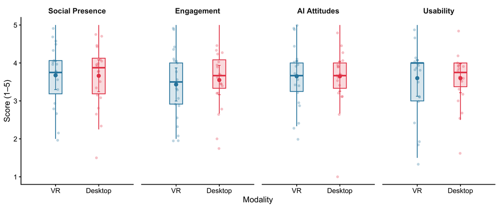

Figure 2. Scale scores by modality (*N* = 20). Jittered points = individual sessions. Box = IQR; whiskers = 1.5 × IQR. Circle with error bars = mean ± 95% CI.

## 7.2 Figure 3: Effect Size Forest Plot

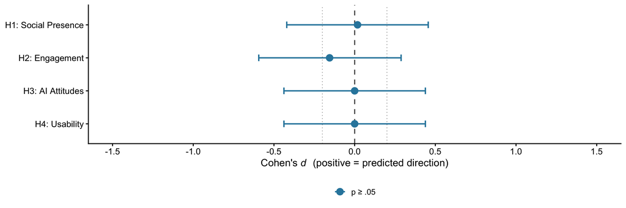

Figure 3. Cohen’s *d* with 95% CI for H1–H4. Dashed line = no effect. Dotted lines = small-effect benchmark (|*d*| = 0.20; Cohen, 1988). Positive = predicted direction supported.

## 7.3 Figure 4: Modality × Order Interaction Plots

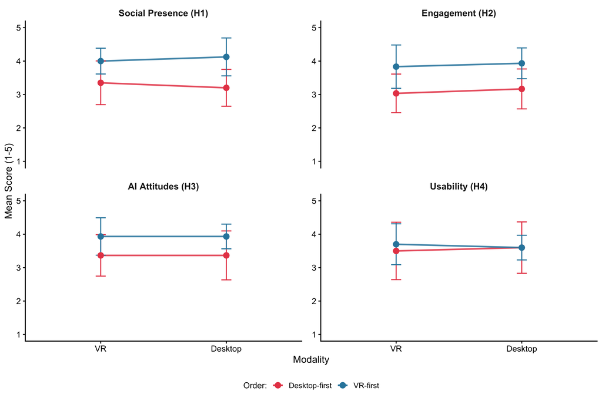

Figure 4. Modality × Order interaction plots for all four outcome variables. Points = cell means; error bars = 95% CI (t-based). Parallel lines indicate no interaction; crossing lines would suggest the modality effect depends on counterbalancing order.

## 7.4 Figure 5: Within-Person Trajectories

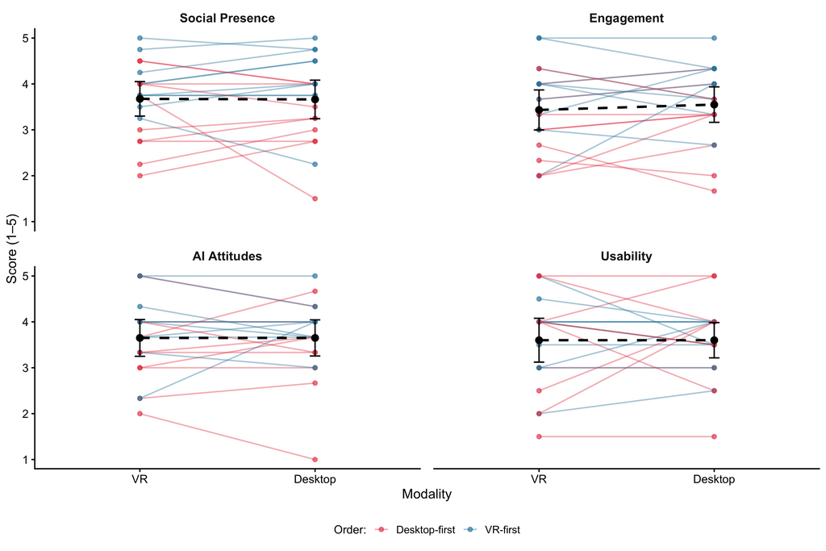

Figure 5. Individual participant score changes by modality, coloured by counterbalancing order. Dashed black line = group mean ± 95% CI.

# 8 Exploratory Analyses

> These analyses were not pre-registered or were modified from the preregistered plan.

## 8.1 Baseline Loneliness and Social Presence

Baseline loneliness (UCLA-3) was examined as an exploratory moderator of social presence. UCLA-3 is a single baseline measure — it does not vary within participants across sessions — so Spearman correlations at the participant level are used: loneliness against VR-only and Desktop-only social presence. Holm correction is applied across both tests.

Table 5. UCLA Loneliness × Social Presence: Spearman correlations (N = 20).

| Condition | Statistic | p (raw) | p (Holm) | p < .05 |
| --- | --- | --- | --- | --- |
| VR | ρ = .57 | .009 | .018 | TRUE |
| Desktop | ρ = .34 | .149 | .149 | FALSE |

Note. ρ = Spearman rank correlation at the participant level. UCLA-3 is a fixed baseline measure so repeated-measures correlation is not used. Holm–Bonferroni correction applied across both tests. Positive values indicate lonelier participants reported greater social presence.

## 8.2 Within-Subject Loneliness Preference

Does baseline loneliness predict which modality produced higher social presence for each participant? A positive correlation would mean lonelier participants showed a larger VR advantage. The direction was specified a priori (lonelier → larger VR advantage), so a one-tailed test is used.

Table 6. Loneliness predicting within-subject VR–Desktop SP difference.

| ρ | p (one-tailed) | p (two-tailed) | n | Note |
| --- | --- | --- | --- | --- |
| 0.433 | .028 | .056 | 20 | Positive = lonelier participants preferred VR |

Note. One-tailed test used because the direction (lonelier → larger VR advantage) was specified before analysis. Two-tailed p reported for transparency.

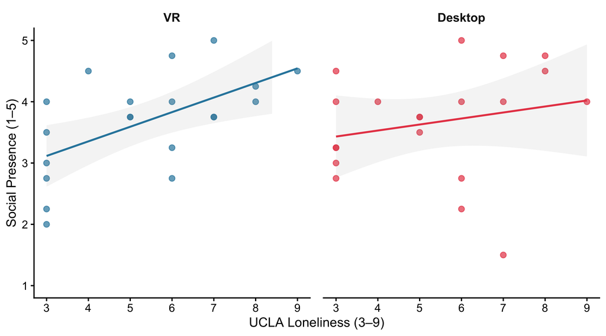

Figure 6. UCLA Loneliness and Social Presence by modality. Lines = linear regression fit ± 95% CI. Exploratory only.

# References

Appelbaum, M., Cooper, H., Kline, R. B., Mayo-Wilson, E., Nezu, A. M., & Rao, S. M. (2018). Journal article reporting standards for quantitative research in psychology. *American Psychologist, 73*(1), 3–25. https://doi.org/10.1037/amp0000191

Bakdash, J. Z., & Marusich, L. R. (2017). Repeated measures correlation. *Frontiers in Psychology, 8*, 456. https://doi.org/10.3389/fpsyg.2017.00456

Cohen, J. (1988). *Statistical power analysis for the behavioral sciences* (2nd ed.). Lawrence Erlbaum Associates.

Field, A. (2024). *Discovering statistics using IBM SPSS Statistics* (6th ed.). SAGE.

Hughes, M. E., Waite, L. J., Hawkley, L. C., & Cacioppo, J. T. (2004). A short scale for measuring loneliness in large surveys: Results from two population-based studies. *Research on Aging, 26*(6), 655–672. https://doi.org/10.1177/0164027504268574

Olejnik, S., & Algina, J. (2003). Generalized eta and omega squared statistics: Measures of effect size for some common research designs. *Psychological Methods, 8*(4), 434–447. https://doi.org/10.1037/1082-989X.8.4.434

Steiger, J. H. (2004). Beyond the F test: Effect size confidence intervals and tests of close fit in the analysis of variance and contrast analysis. *Psychological Methods, 9*(2), 164–182. https://doi.org/10.1037/1082-989X.9.2.164

Steptoe, A., Shankar, A., Demakakos, P., & Wardle, J. (2013). Social isolation, loneliness, and all-cause mortality in older men and women. *Proceedings of the National Academy of Sciences, 110*(15), 5797–5801. https://doi.org/10.1073/pnas.1219686110

# 9 Appendix

# A: UCLA Loneliness Distribution

Bands from Steptoe et al. (2013); scale validated by Hughes et al. (2004).

Table A1. UCLA-3 Loneliness distribution (N = 20 participants).

| Band | n | % |
| --- | --- | --- |
| Low (3–5) | 10 | 50 |
| Moderate (6–7) | 7 | 35 |
| High (8–9) | 3 | 15 |

# B: Outcome Descriptives by Modality

Table A2. Outcome index descriptives by modality (N = 20 participants, 40 sessions).

| Modality | n | SP_M | SP_SD | EN_M | EN_SD | AT_M | AT_SD | US_M | US_SD | Dur_M | Dur_SD |
| --- | --- | --- | --- | --- | --- | --- | --- | --- | --- | --- | --- |
| VR | 20 | 3.67 | 0.8 | 3.43 | 0.93 | 3.65 | 0.85 | 3.6 | 1.02 | 17.6 | 11.3 |
| Desktop | 20 | 3.66 | 0.9 | 3.55 | 0.83 | 3.65 | 0.84 | 3.6 | 0.82 | 17.2 | 13.5 |

Note. SP = Social Presence; EN = Engagement; AT = AI Attitudes; US = Usability; Dur = Duration (min).

# C: Interaction Duration

Duration is the study’s only objective behavioural measure, recorded independently of self-report. **[UNPLANNED]** An exploratory Wilcoxon signed-rank test was added at researcher request.

Table A3. Interaction duration by modality — Wilcoxon signed-rank [UNPLANNED].

| VR M (SD) | Desktop M (SD) | V | p | r_rb |
| --- | --- | --- | --- | --- |
| 17.6 (11.3) | 17.2 (13.5) | 114 | .456 | 0.2 |

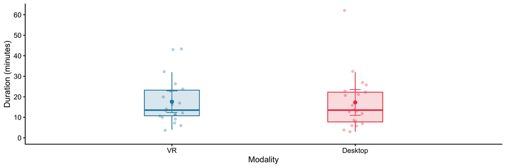

Figure A1. Session duration (minutes) by modality. Jittered points = individual sessions. Box = IQR; whiskers = 1.5 × IQR. Circle with error bars = mean ± 95% CI.

# D: Sensitivity Analyses

Three robustness checks examine whether the primary null results depend on inclusion decisions. A non-significant result under each alternative sample is consistent with, but does not on its own demonstrate, a true absence of effect.

Table A4. Sensitivity analyses: Modality main effect across three alternative samples.

| Check | N | Hypothesis | p (adj) | d |
| --- | --- | --- | --- | --- |
| Check 1: ≥5 min only | 17 | H1 SP | 0.936 | 0.021 |
| Check 1: ≥5 min only | 17 | H2 EN | 1.000 | 0.032 |
| Check 1: ≥5 min only | 17 | H3 AT | 1.000 | 0.147 |
| Check 1: ≥5 min only | 17 | H4 US | 1.000 | -0.063 |
| Check 2: Technical difficulties removed | 15 | H1 SP | 0.897 | 0.084 |
| Check 2: Technical difficulties removed | 15 | H2 EN | 1.000 | -0.138 |
| Check 2: Technical difficulties removed | 15 | H3 AT | 1.000 | 0.068 |
| Check 2: Technical difficulties removed | 15 | H4 US | 1.000 | 0.034 |
| Check 3: All 22 participants (incl. P03, P04) | 22 | H1 SP | 0.759 | 0.067 |
| Check 3: All 22 participants (incl. P03, P04) | 22 | H2 EN | 1.000 | -0.061 |
| Check 3: All 22 participants (incl. P03, P04) | 22 | H3 AT | 1.000 | 0.000 |
| Check 3: All 22 participants (incl. P03, P04) | 22 | H4 US | 1.000 | 0.052 |

Note. H1 uncorrected; H2-H4 Holm adjusted. Null results were consistent across all three samples, which is compatible with (but does not by itself establish) the absence of a modality effect.

# E: Internal Consistency of Outcome Composites

Each outcome index is the mean of its constituent items. Cronbach’s alpha below is computed on the analysed sample (40 sessions, 20 participants × 2 modalities). Values near or above .80 indicate the items within each scale hang together adequately. Usability has only two items, so its alpha is reported alongside the note that the Spearman–Brown coefficient is the conventional two-item index.

Table E1. Internal consistency (Cronbach’s alpha) of outcome composites (40 sessions).

| Scale | Items | k | Cronbach’s α |
| --- | --- | --- | --- |
| Social Presence | sp1–sp4 | 4 | 0.79 |
| Engagement | en1–en3 | 3 | 0.75 |
| AI Attitudes | at1–at3 | 3 | 0.80 |
| Usability | us1–us2 | 2 | 0.80 |

Note. k = number of items. Alpha computed on analysed sessions. The two-item usability scale is shown for completeness; Spearman–Brown is the preferred two-item coefficient.

Software and package versions.

| Package | Version |
| --- | --- |
| R | 4.5.3 |
| tidyverse | 2.0.0 |
| lubridate | 1.9.5 |
| ez | 4.5.0 |
| lme4 | 2.0.1 |
| lmerTest | 3.2.1 |
| effectsize | 1.0.2 |
| car | 3.1.5 |
| kableExtra | 1.4.0 |